# Est_RegSim

Yong Yoon

2022-07-12

## Estimations (Part A)

The general model for estimation is as follows:

$$\begin{align*}
\text{ln } p_{ijk} &= \alpha + \beta sim_{ij} + \gamma_1 \rho_k +
\gamma_2 \theta_{ij} + \gamma_3 tariff_{ijk} \\
& + \gamma_4 NTM_{ijk}^{Tech} + \gamma_5 NTM_{ijk}^{Non-Tech} +
\gamma_{6i}(NTM_{ijk}^{Tech} \times \delta_i) +
\gamma_{7i}(NTM_{ijk}^{Non-Tech} \times \delta_i) \\
& + \gamma_8 DIG_i + \epsilon_{ijk}
\end{align*}$$

where

| $DIG_i$ | is the average score of separate Pillar measures capturing digital-trade regulation imposed by country $i$ on all imports |
| --- | --- |
| $\rho$ | is the HS6 product fixed effects dummy variable (since regressions are estimated at chapter-level (i.e. there are **96 separate regressions**) |
| $\theta$ | is the pair characteristics (i.e. distance, contiguity, landlocked status, common language, and RTA) |
| $tariff_{ijk}$ | is the applied tariff (MFN or lowest preferential, if available) imposed by $i$ on imports of product $k$ from $j$ |
| $NTM_{ijk}^{Tech}$ | is the count of separate non-tariff measures from chapters A to C imposed by $i$ on imports of product $k$ from $j$ |
| $NTM_{ijk}^{Non-Tech}$ | is the count of separate non-tariff measures from chapters D to O imposed by $i$ on imports of product $k$ from $j$ |
| $sim_{ij}$ | is a measure of regulatory similarity of country $i$ and $j$ |
| $\delta_{i}$ | is fixed effect of country $i$ (included for interaction with $NTM$) |

# Model 1

$$\begin{align*}
\text{ln } p_{ijk} &= \alpha + \beta sim_{ij} + \gamma_1 \rho_k +
\epsilon_{ijk}
\end{align*}$$

```r
library(dplyr)

dta.df <- as.data.frame(cbind(HS_2, results.A, results.B))
colnames(dta.df) <- c('HS2','n','Adj-R2', 'b_regsim', 'p')

dta.df$bRegsim <- with(dta.df, ifelse(p > 0.1, 0, b_regsim))
dta.df_ <- as.data.frame(sapply(dta.df, as.numeric))

head(select(dta.df, -b_regsim))                 # head(dta.df)
```

```
##   HS2    n            Adj-R2                  p            bRegsim
## 1  01  347 0.546717450461031  0.728020170702463                  0
## 2  02  946 0.441937426272814  0.447902023197201                  0
## 3  03 5798 0.390320279036154  0.859296230446902                  0
## 4  04 1681 0.368535141350099  0.731020169025494                  0
## 5  05  565 0.263107453066832   0.31661819904167                  0
## 6  06  849 0.512208412429365 0.0832446586510528 -0.853658835785104
```

```r
regsim_sig.M1 <- nrow(dta.df_[dta.df_$bRegsim!=0,])
regsim_sig.POS.M1 <- nrow(dta.df_[dta.df_$bRegsim>0,])
regsim_sig.NEG.M1 <- nrow(dta.df_[dta.df_$bRegsim<0,])
Adj_R.avg.M1 <- mean(dta.df_[['Adj-R2']])
```

When considering 96-sectors (at the HS-2 level), we find only 11 digital measure coefficients (of which 0 are positive and 11 are negative) to be significant at the 10 percent level, and the average Adjusted R-square of the regressions is 0.3496806 .

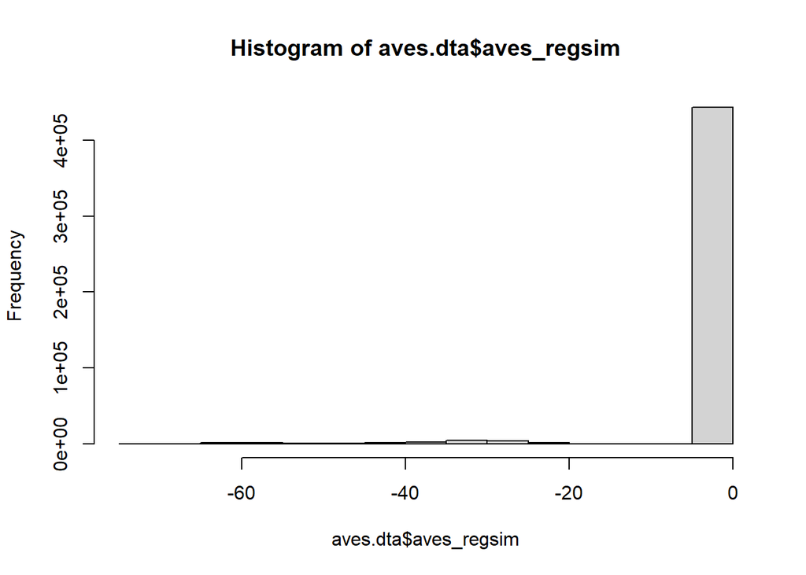

```r
aves.dta <- read.csv(paste0(path_, "aves_", model, ".csv"))
hist(aves.dta$aves_regsim)
```

```r
# weighted.mean(aves.dta$aves_digital, aves.dta$tradevalue, na.rm = TRUE)
```

```r
aves.dta$NPos <- ifelse(aves.dta$aves_regsim>0,0,aves.dta$aves_regsim)
# class(aves.dta$POS)
mean(aves.dta$aves_regsim, na.rm=TRUE)
```

```
## [1] -1.884183
```

```r
print(AVES_mean.M1 <- weighted.mean(aves.dta$aves_regsim, aves.dta$tradevalue, na.rm = TRUE))
```

```
## [1] -1.917133
```

```r
mean(aves.dta$aves_regsimNPos, na.rm=TRUE)
```

```
## [1] -0.7138406
```

```r
print(AVES_mean_NPos.M1 <- weighted.mean(aves.dta$aves_regsimNPos, aves.dta$tradevalue, na.rm = TRUE))
```

```
## [1] -1.026391
```

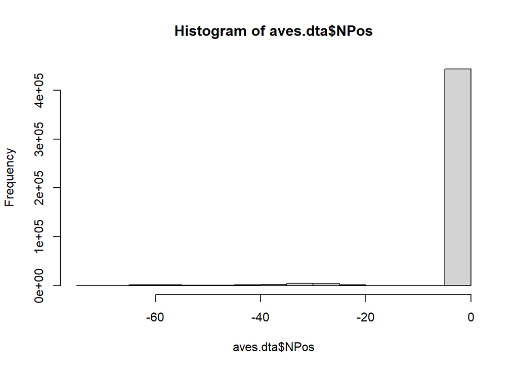

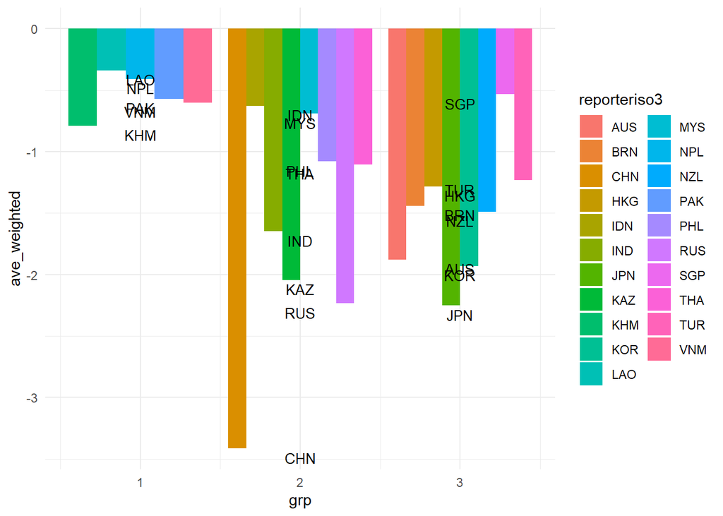

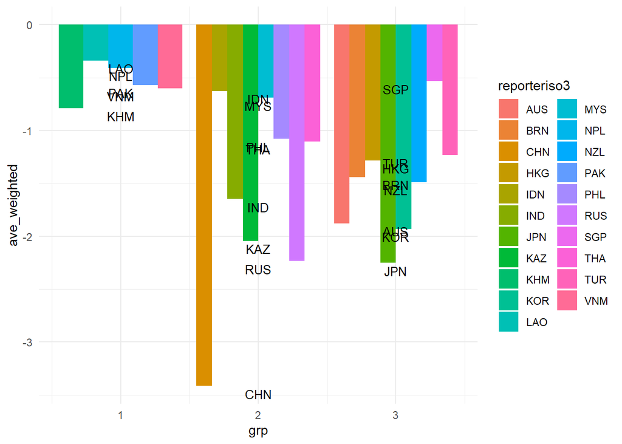

```r
hist(aves.dta$NPos)
```

The average weighted (by trade value) is -1.9171326 (and -1.0263908 when considering non-positive AVEs) Further note that the fraction of negative AVES is 0.0480264 ; zero AVES is 0.9519736 and positive AVES is 0.

# Model 2

$$\begin{align*}
\text{ln } p_{ijk} &= \alpha + \beta sim_{ij} + \gamma_1 \rho_k +
\gamma_2 \theta_{ij} + \gamma_3 tariff_{ijk} + \epsilon_{ijk}
\end{align*}$$

```r
library(dplyr)

dta.df <- as.data.frame(cbind(HS_2, results.A, results.B))
colnames(dta.df) <- c('HS2','n','Adj-R2', 'b_regsim', 'p')

dta.df$bRegsim <- with(dta.df, ifelse(p > 0.1, 0, b_regsim))
dta.df_ <- as.data.frame(sapply(dta.df, as.numeric))

head(select(dta.df, -b_regsim))                 # head(dta.df)
```

```
##   HS2    n            Adj-R2                  p           bRegsim
## 1  01  347 0.567235501058362   0.40546968080929                 0
## 2  02  946 0.462135608522066  0.412950031475648                 0
## 3  03 5798 0.442202399005705   0.77364434443959                 0
## 4  04 1681 0.393881897134845 0.0934641801770036 0.415276900687573
## 5  05  565 0.313334380990202  0.448031617064207                 0
## 6  06  849  0.54528432254568 0.0282547565179694  -1.1141677252073
```

```r
regsim_sig.M2 <- nrow(dta.df_[dta.df_$bRegsim!=0,])
regsim_sig.POS.M2 <- nrow(dta.df_[dta.df_$bRegsim>0,])
regsim_sig.NEG.M2 <- nrow(dta.df_[dta.df_$bRegsim<0,])
Adj_R.avg.M2 <- mean(dta.df_[['Adj-R2']])
```

When considering 96-sectors (at the HS-2 level), we find only 8 digital measure coefficients (of which 3 are positive and 5 are negative) to be significant at the 10 percent level, and the average Adjusted R-square of the regressions is 0.3800157 .

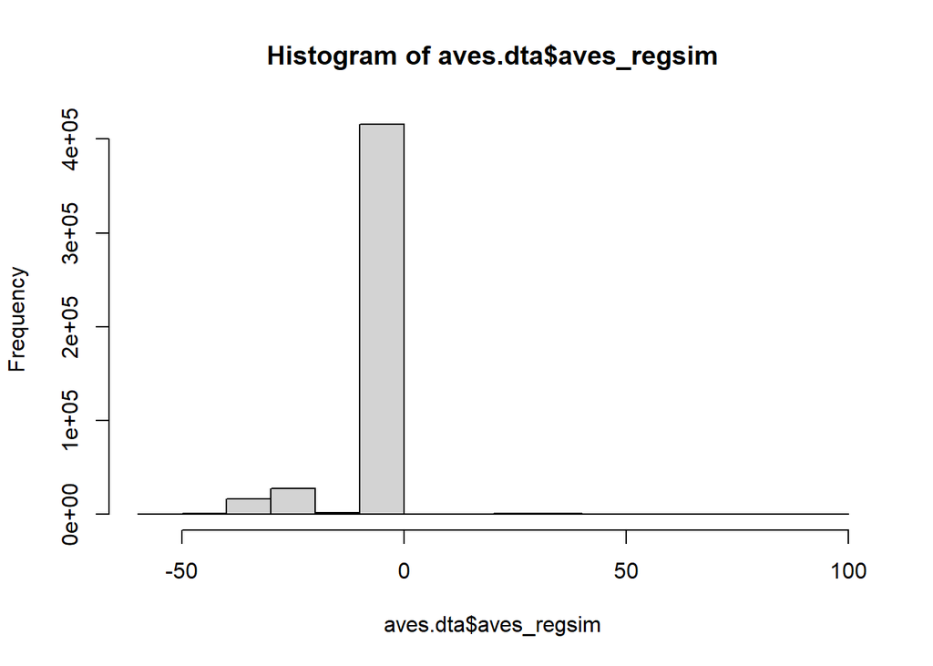

```r
aves.dta <- read.csv(paste0(path_, "aves_", model, ".csv"))
hist(aves.dta$aves_regsim)
```

```r
# weighted.mean(aves.dta$aves_digital, aves.dta$tradevalue, na.rm = TRUE)
```

```r
aves.dta$NPos <- ifelse(aves.dta$aves_regsim>0,0,aves.dta$aves_regsim)
# class(aves.dta$POS)
mean(aves.dta$aves_regsim, na.rm=TRUE)
```

```
## [1] -2.640238
```

```r
print(AVES_mean.M2 <- weighted.mean(aves.dta$aves_regsim, aves.dta$tradevalue, na.rm = TRUE))
```

```
## [1] -8.025104
```

```r
mean(aves.dta$aves_regsimNPos, na.rm=TRUE)
```

```
## [1] -1.091989
```

```r
print(AVES_mean_NPos.M2 <- weighted.mean(aves.dta$aves_regsimNPos, aves.dta$tradevalue, na.rm = TRUE))
```

```
## [1] -4.355363
```

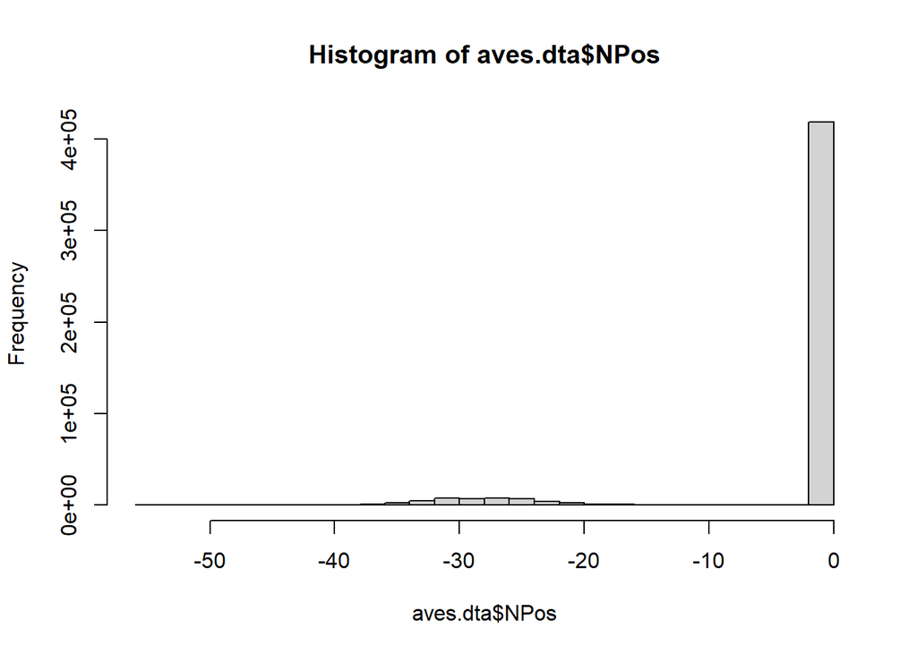

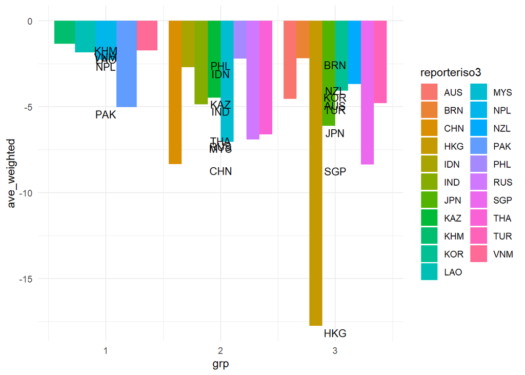

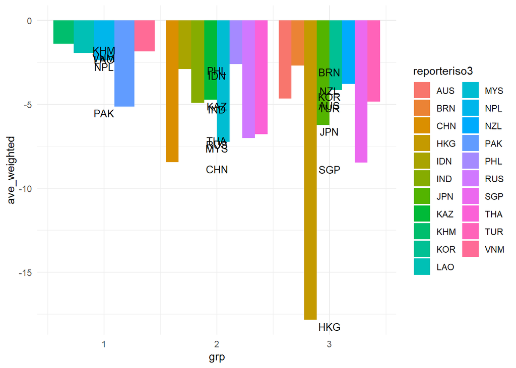

```r
hist(aves.dta$NPos)
```

The average weighted (by trade value) is -8.0251038 (and -4.3553625 when considering non-positive AVEs) Further note that the fraction of negative AVES is 0.1008444 ; zero AVES is 0.893169 and positive AVES is 0.0059866.

# Model 3

$$\begin{align*}
\text{ln } p_{ijk} &= \alpha + \beta sim_{ij} + \gamma_1 \rho_k +
\gamma_2 \theta_{ij} + \gamma_3 tariff_{ijk} \\
& + \gamma_4 NTM_{ijk}^{Tech} + \gamma_5 NTM_{ijk}^{Non-Tech} +
\epsilon_{ijk}
\end{align*}$$

```r
library(dplyr)

dta.df <- as.data.frame(cbind(HS_2, results.A, results.B))
colnames(dta.df) <- c('HS2','n','Adj-R2', 'b_regsim', 'p')

dta.df$bRegsim <- with(dta.df, ifelse(p > 0.1, 0, b_regsim))
dta.df_ <- as.data.frame(sapply(dta.df, as.numeric))

head(select(dta.df, -b_regsim))                 # head(dta.df)
```

```
##   HS2    n            Adj-R2                  p          bRegsim
## 1  01  347 0.570250619666477  0.518147872390644                0
## 2  02  946 0.464017001198546  0.403696372302834                0
## 3  03 5798 0.443371285875352  0.690401244319208                0
## 4  04 1681 0.395559054619719  0.186680904106928                0
## 5  05  565 0.325442521913478  0.600196291454596                0
## 6  06  849 0.548028157200579 0.0284766718988053 -1.0750365728697
```

```r
regsim_sig.M3 <- nrow(dta.df_[dta.df_$bRegsim!=0,])
regsim_sig.POS.M3 <- nrow(dta.df_[dta.df_$bRegsim>0,])
regsim_sig.NEG.M3 <- nrow(dta.df_[dta.df_$bRegsim<0,])
Adj_R.avg.M3 <- mean(dta.df_[['Adj-R2']])
```

When considering 96-sectors (at the HS-2 level), we find only 7 digital measure coefficients (of which 2 are positive and 5 are negative) to be significant at the 10 percent level, and the average Adjusted R-square of the regressions is 0.3830089 .

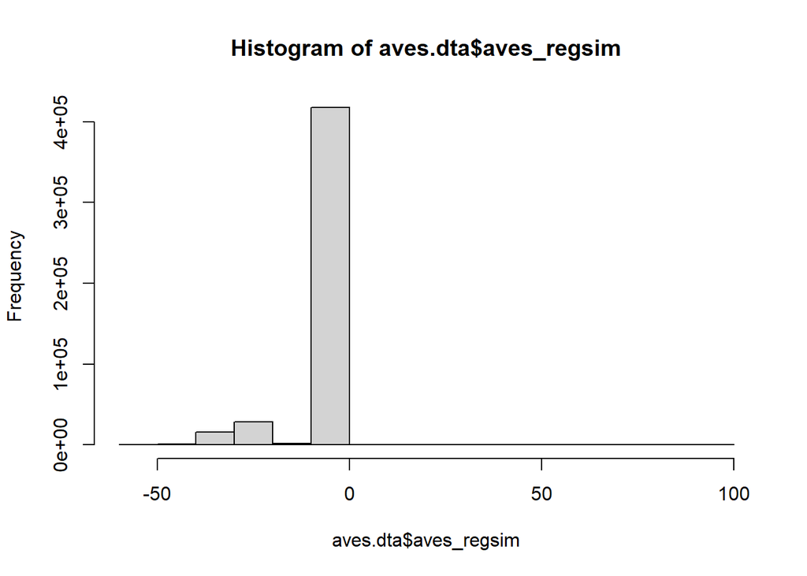

```r
aves.dta <- read.csv(paste0(path_, "aves_", model, ".csv"))
hist(aves.dta$aves_regsim)
```

```r
# weighted.mean(aves.dta$aves_digital, aves.dta$tradevalue, na.rm = TRUE)
```

```r
aves.dta$NPos <- ifelse(aves.dta$aves_regsim>0,0,aves.dta$aves_regsim)
# class(aves.dta$POS)
mean(aves.dta$aves_regsim, na.rm=TRUE)
```

```
## [1] -2.719376
```

```r
print(AVES_mean.M3 <- weighted.mean(aves.dta$aves_regsim, aves.dta$tradevalue, na.rm = TRUE))
```

```
## [1] -8.027669
```

```r
mean(aves.dta$aves_regsimNPos, na.rm=TRUE)
```

```
## [1] -1.083122
```

```r
print(AVES_mean_NPos.M3 <- weighted.mean(aves.dta$aves_regsimNPos, aves.dta$tradevalue, na.rm = TRUE))
```

```
## [1] -4.311574
```

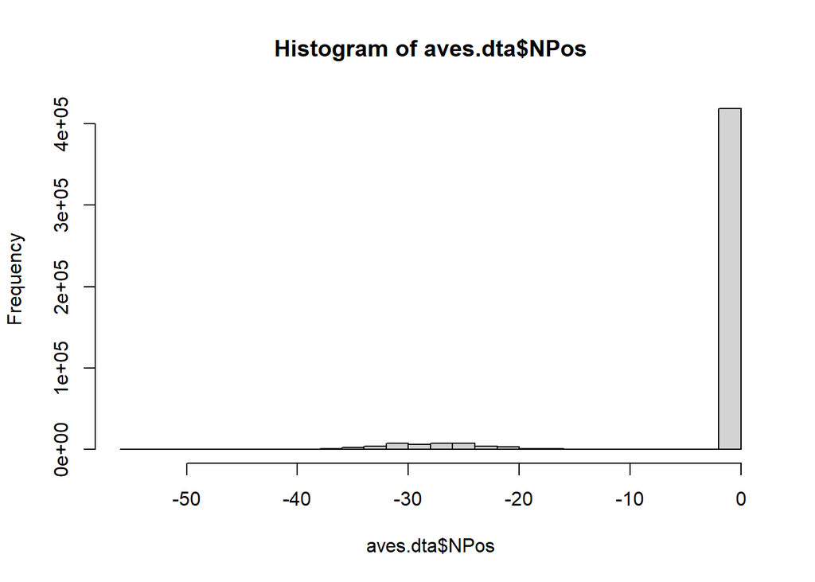

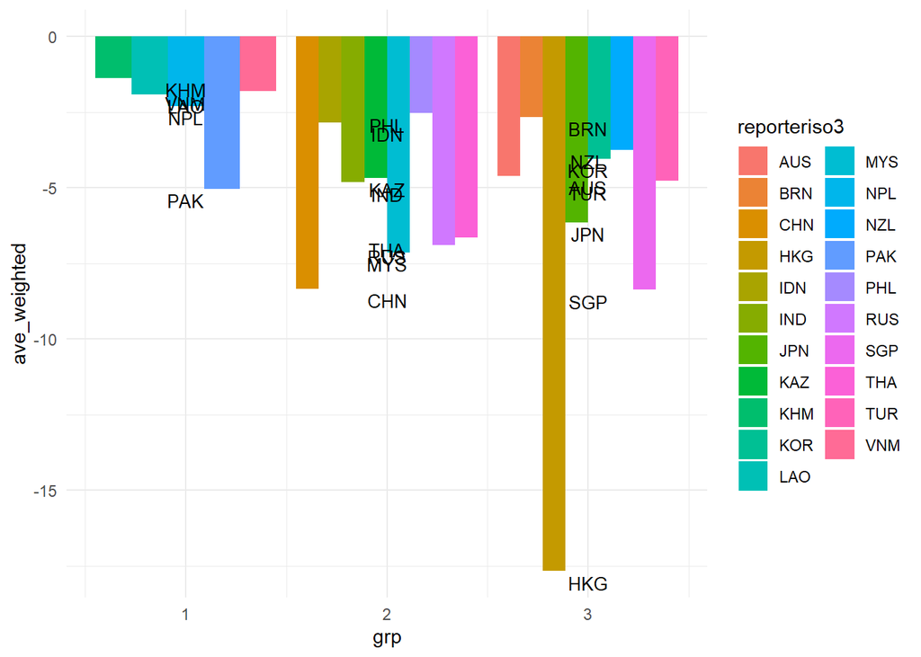

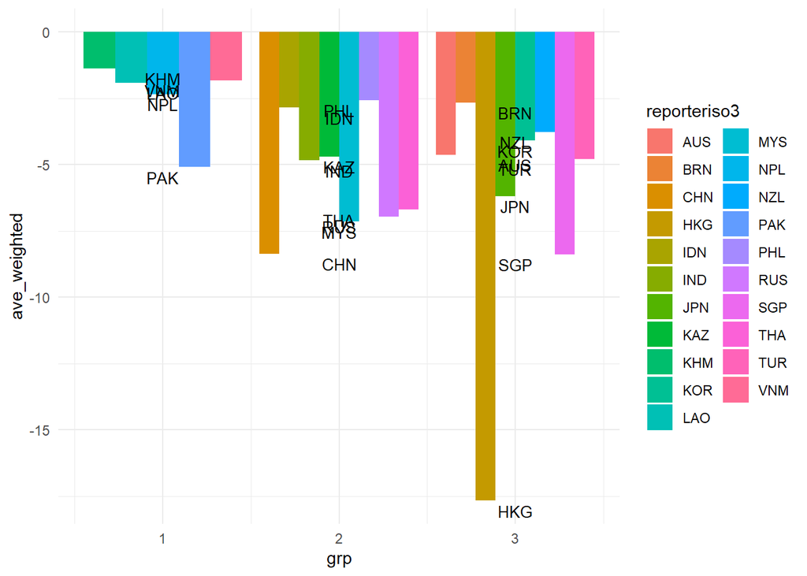

```r
hist(aves.dta$NPos)
```

The average weighted (by trade value) is -8.0276685 (and -4.3115741 when considering non-positive AVEs) Further note that the fraction of negative AVES is 0.1008444 ; zero AVES is 0.8967825 and positive AVES is 0.0023732.

# Model 3 (with Digital) = Model 4

$$\begin{align*}
\text{ln } p_{ijk} &= \alpha + \beta sim_{ij} + \gamma_1 \rho_k +
\gamma_2 \theta_{ij} + \gamma_3 tariff_{ijk} \\
& + \gamma_4 NTM_{ijk}^{Tech} + \gamma_5 NTM_{ijk}^{Non-Tech} +
\beta DIG_i + \epsilon_{ijk}
\end{align*}$$

```r
library(dplyr)

dta.df <- as.data.frame(cbind(HS_2, results.A, results.B))
colnames(dta.df) <- c('HS2','n','Adj-R2', 'b_regsim', 'p')

dta.df$bRegsim <- with(dta.df, ifelse(p > 0.1, 0, b_regsim))
dta.df_ <- as.data.frame(sapply(dta.df, as.numeric))

head(select(dta.df, -b_regsim))                 # head(dta.df)
```

```
##   HS2    n            Adj-R2                  p          bRegsim
## 1  01  347 0.569658191589087  0.511219335206182                0
## 2  02  946 0.463481100692357  0.405578535023069                0
## 3  03 5798 0.443274221570381  0.688634661970065                0
## 4  04 1681 0.396276705413282  0.174369835933365                0
## 5  05  565 0.327132952140953  0.638879171507792                0
## 6  06  849 0.547543708247916 0.0286324599812634 -1.0728226663465
```

```r
regsim_sig.M4 <- nrow(dta.df_[dta.df_$bRegsim!=0,])
regsim_sig.POS.M4 <- nrow(dta.df_[dta.df_$bRegsim>0,])
regsim_sig.NEG.M4 <- nrow(dta.df_[dta.df_$bRegsim<0,])
Adj_R.avg.M4 <- mean(dta.df_[['Adj-R2']])
```

When considering 96-sectors (at the HS-2 level), we find only 7 digital measure coefficients (of which 2 are positive and 5 are negative) to be significant at the 10 percent level, and the average Adjusted R-square of the regressions is 0.3865028 .

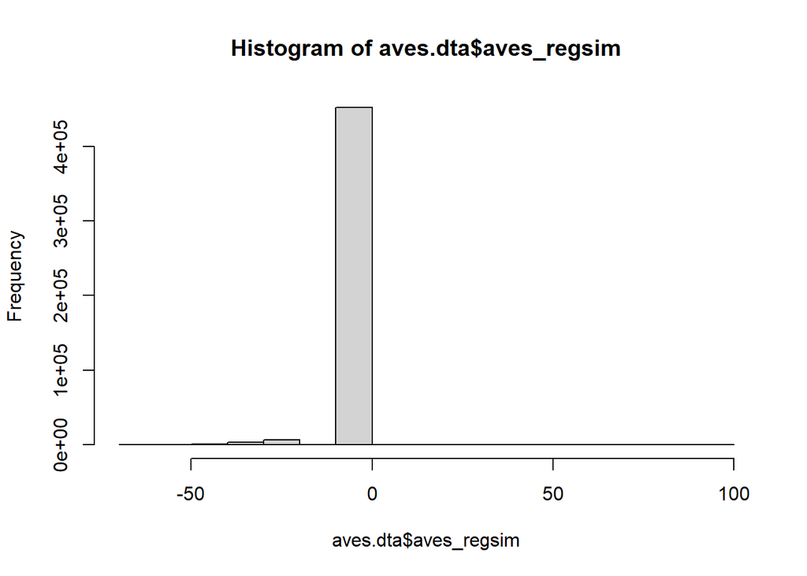

```r
aves.dta <- read.csv(paste0(path_, "aves_", model, ".csv"))
hist(aves.dta$aves_regsim)
```

```r
# weighted.mean(aves.dta$aves_digital, aves.dta$tradevalue, na.rm = TRUE)
```

```r
aves.dta$NPos <- ifelse(aves.dta$aves_regsim>0,0,aves.dta$aves_regsim)
# class(aves.dta$POS)
mean(aves.dta$aves_regsim, na.rm=TRUE)
```

```
## [1] -0.7041331
```

```r
print(AVES_mean.M4 <- weighted.mean(aves.dta$aves_regsim, aves.dta$tradevalue, na.rm = TRUE))
```

```
## [1] -0.5712427
```

```r
mean(aves.dta$aves_regsimNPos, na.rm=TRUE)
```

```
## [1] -0.3198125
```

```r
print(AVES_mean_NPos.M4 <- weighted.mean(aves.dta$aves_regsimNPos, aves.dta$tradevalue, na.rm = TRUE))
```

```
## [1] -0.319488
```

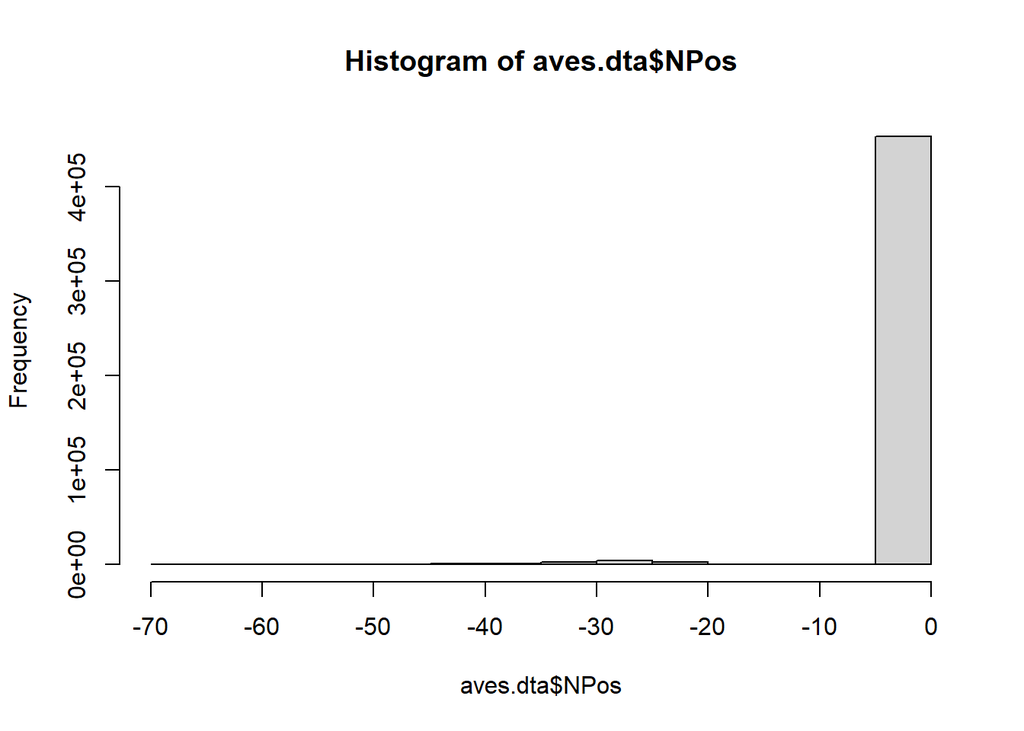

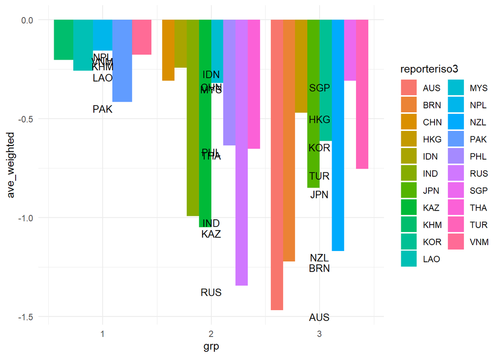

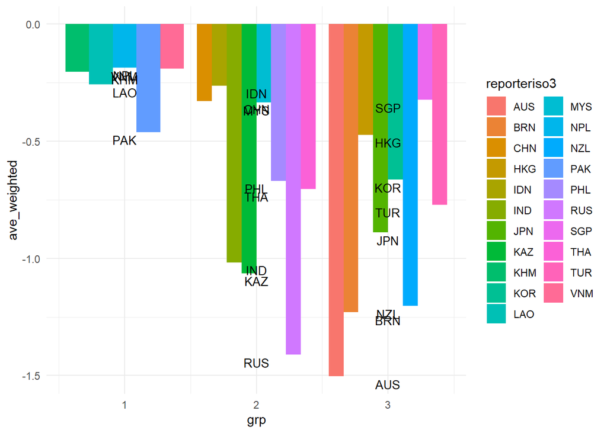

```r
hist(aves.dta$NPos)
```

The average weighted (by trade value) is -0.5712427 (and -0.319488 when considering non-positive AVEs) Further note that the fraction of negative AVES is 0.0268593 ; zero AVES is 0.9707675 and positive AVES is 0.0023732.

# Model 5

$$\begin{align*}
\text{ln } p_{ijk} &= \alpha + \beta sim_{ij} + \gamma_1 \rho_k +
\gamma_2 \theta_{ij} + \gamma_3 tariff_{ijk} \\
& + \gamma_4 NTM_{ijk}^{Tech} + \gamma_5 NTM_{ijk}^{Non-Tech} \\
& + \gamma_{6i}(NTM_{ijk}^{Tech} \times \delta_i) +
\gamma_{7i}(NTM_{ijk}^{Non-Tech} \times \delta_i) + \epsilon_{ijk}
\end{align*}$$

```r
library(dplyr)

dta.df <- as.data.frame(cbind(HS_2, results.A, results.B))
colnames(dta.df) <- c('HS2','n','Adj-R2', 'b_regsim', 'p')

dta.df$bRegsim <- with(dta.df, ifelse(p > 0.1, 0, b_regsim))
dta.df_ <- as.data.frame(sapply(dta.df, as.numeric))

head(select(dta.df, -b_regsim))                 # head(dta.df)
```

```
##   HS2    n            Adj-R2                  p            bRegsim
## 1  01  347 0.612316589917735  0.837950735940504                  0
## 2  02  946 0.504971376264246  0.259356132194441                  0
## 3  03 5798 0.477319723102728  0.751712112308582                  0
## 4  04 1681  0.43408764209193  0.277421879659243                  0
## 5  05  565 0.390967157486094   0.44051520187216                  0
## 6  06  849 0.581804748732573 0.0753520600889731 -0.671283632913384
```

```r
regsim_sig.M5_ <- nrow(dta.df_[dta.df_$bRegsim!=0,])
regsim_sig.POS.M5_ <- nrow(dta.df_[dta.df_$bRegsim>0,])
regsim_sig.NEG.M5_ <- nrow(dta.df_[dta.df_$bRegsim<0,])
Adj_R.avg.M5_ <- mean(dta.df_[['Adj-R2']])
```

When considering 96-sectors (at the HS-2 level), we find only 15 digital measure coefficients (of which 2 are positive and 13 are negative) to be significant at the 10 percent level, and the average Adjusted R-square of the regressions is 0.4211809 .

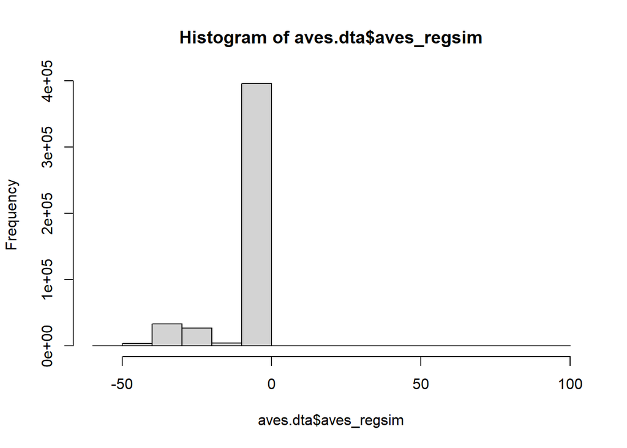

```r
aves.dta <- read.csv(paste0(path_, "aves_", model, ".csv"))
hist(aves.dta$aves_regsim)
```

```r
# weighted.mean(aves.dta$aves_digital, aves.dta$tradevalue, na.rm = TRUE)
```

```r
aves.dta$NPos <- ifelse(aves.dta$aves_regsim>0,0,aves.dta$aves_regsim)
# class(aves.dta$POS)
mean(aves.dta$aves_regsim, na.rm=TRUE)
```

```
## [1] -4.32181
```

```r
print(AVES_mean.M5_ <- weighted.mean(aves.dta$aves_regsim, aves.dta$tradevalue, na.rm = TRUE))
```

```
## [1] -9.908523
```

```r
mean(aves.dta$aves_regsimNPos, na.rm=TRUE)
```

```
## [1] -1.693386
```

```r
print(AVES_mean_NPos.M5_ <- weighted.mean(aves.dta$aves_regsimNPos, aves.dta$tradevalue, na.rm = TRUE))
```

```
## [1] -5.319393
```

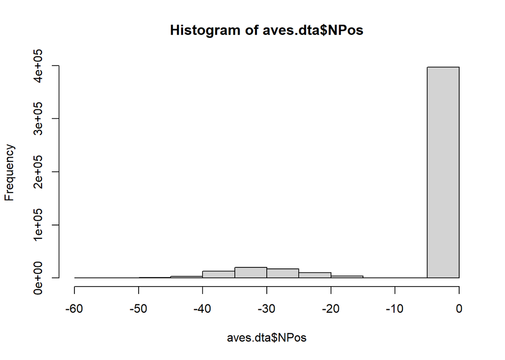

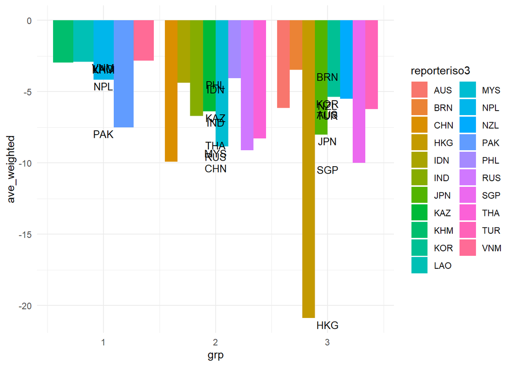

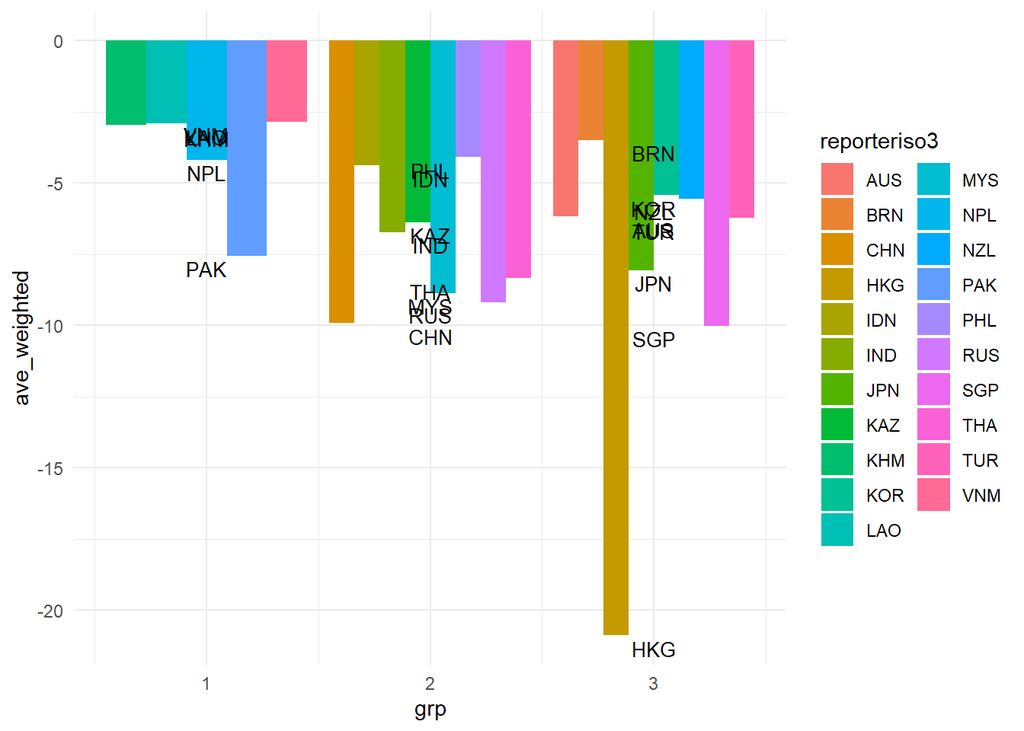

```r
hist(aves.dta$NPos)
```

The average weighted (by trade value) is -9.9085233 (and -5.3193929 when considering non-positive AVEs) Further note that the fraction of negative AVES is 0.1471597 ; zero AVES is 0.8504671 and positive AVES is 0.0023732.

# Model 5 (+ Digital)

$$\begin{align*}
\text{ln } p_{ijk} &= \alpha + \beta sim_{ij} + \gamma_1 \rho_k +
\gamma_2 \theta_{ij} + \gamma_3 tariff_{ijk} \\
& + \gamma_4 NTM_{ijk}^{Tech} + \gamma_5 NTM_{ijk}^{Non-Tech} \\
& + \gamma_{6i}(NTM_{ijk}^{Tech} \times \delta_i) +
\gamma_{7i}(NTM_{ijk}^{Non-Tech} \times \delta_i) + \beta DIG_i +
\epsilon_{ijk}
\end{align*}$$

```r
library(dplyr)

dta.df <- as.data.frame(cbind(HS_2, results.A, results.B))
colnames(dta.df) <- c('HS2','n','Adj-R2', 'b_regsim', 'p')

dta.df$bRegsim <- with(dta.df, ifelse(p > 0.1, 0, b_regsim))
dta.df_ <- as.data.frame(sapply(dta.df, as.numeric))

head(select(dta.df, -b_regsim))                 # head(dta.df)
```

```
##   HS2    n            Adj-R2                  p           bRegsim
## 1  01  347  0.61098772690828  0.834496293263065                 0
## 2  02  946 0.504790901976494  0.269529009212599                 0
## 3  03 5798 0.477613039009289  0.765489415868415                 0
## 4  04 1681 0.434379694583005  0.271708776249139                 0
## 5  05  565  0.39143208536494  0.474873928281353                 0
## 6  06  849 0.584339481483768 0.0903376719850265 -0.63755328986329
```

```r
regsim_sig.M5 <- nrow(dta.df_[dta.df_$bRegsim!=0,])
regsim_sig.POS.M5 <- nrow(dta.df_[dta.df_$bRegsim>0,])
regsim_sig.NEG.M5 <- nrow(dta.df_[dta.df_$bRegsim<0,])
Adj_R.avg.M5 <- mean(dta.df_[['Adj-R2']])
```

When considering 96-sectors (at the HS-2 level), we find only 14 digital measure coefficients (of which 2 are positive and 12 are negative) to be significant at the 10 percent level, and the average Adjusted R-square of the regressions is 0.4237376 .

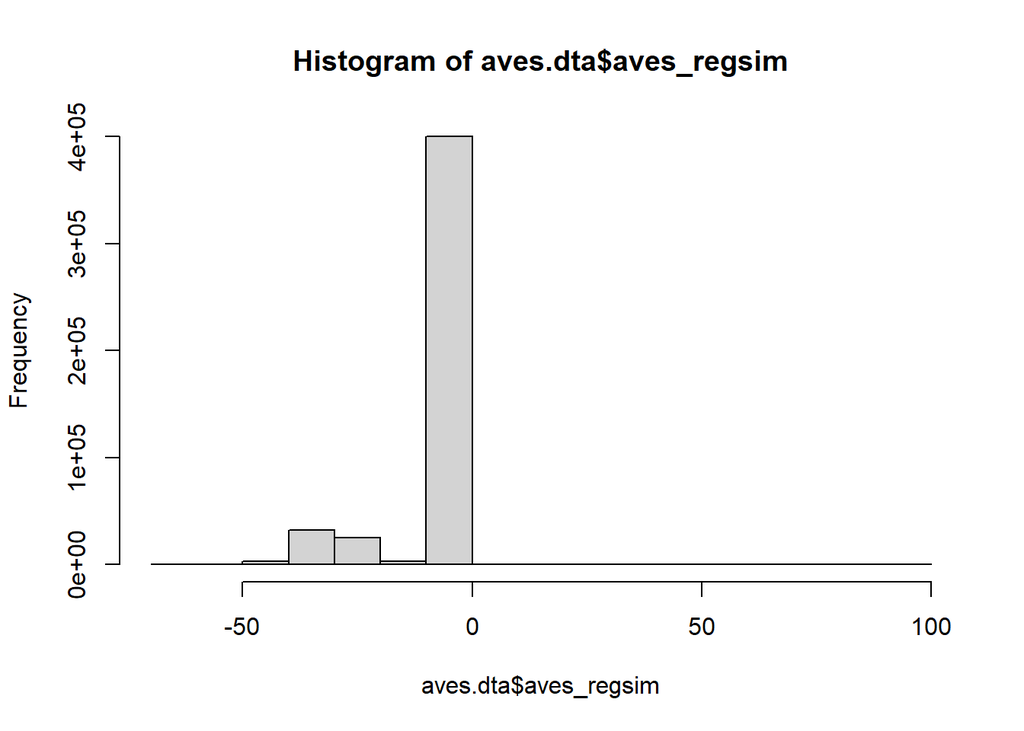

```r
aves.dta <- read.csv(paste0(path_, "aves_", model, ".csv"))
hist(aves.dta$aves_regsim)
```

```r
# weighted.mean(aves.dta$aves_digital, aves.dta$tradevalue, na.rm = TRUE)
```

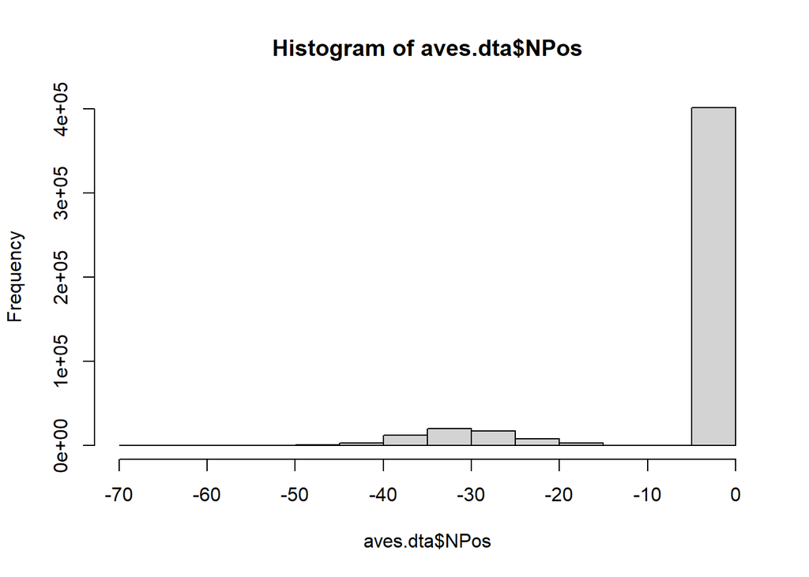

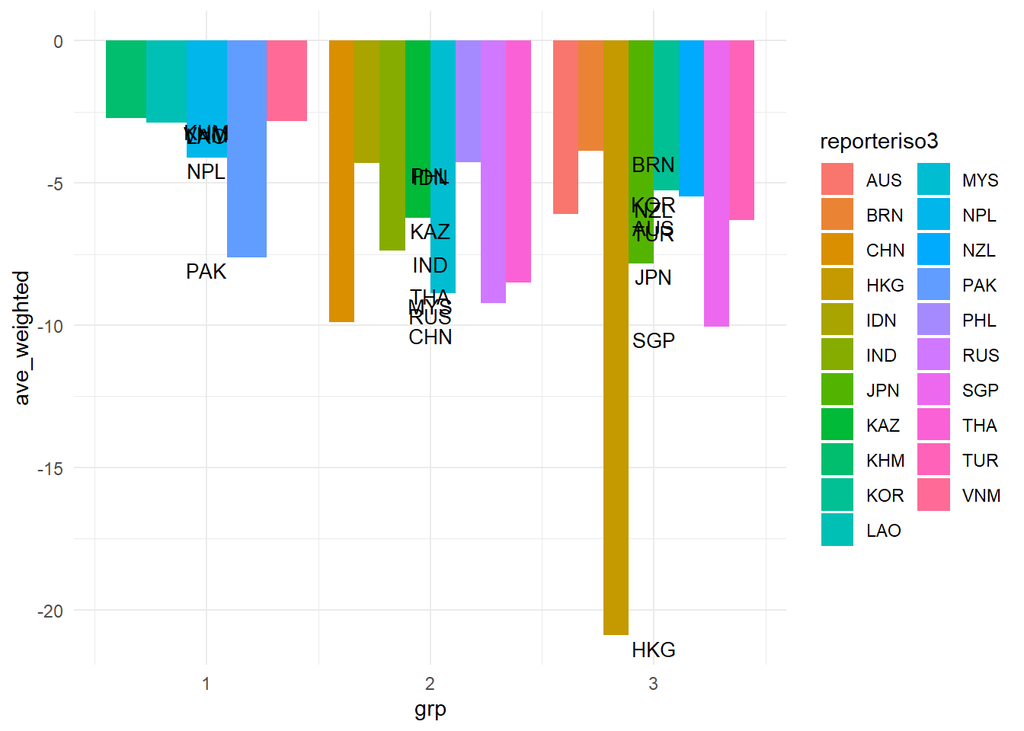

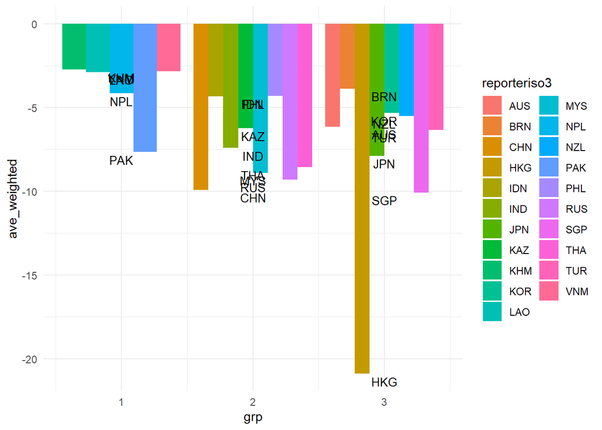

```r
hist(aves.dta$NPos)
```